# R Notes 1 – Probability

## Extra notes

Here are some brief notes on the a few of the distributions that we covered in class that were not covered above.

NOTE that need to pay attention to the parameterization that R uses, slightly different than what we used in class.

### Hypergeometric distribution

Let $X \sim \text{Hypergeometric}(N = 90, M = 9, K = 16)$.

- pmf: $f(x) = {M \choose x} {{N-M} \choose {k-x}} / {N \choose k}$
- Our parameters: $N$ = population size, $M$ = number of objects of interest, $K$ = sample size
- In R, $m = $ number of objects of interest (= our $M$), $n$ = number of objects not of interest = $N - M$, $k$ = sample size (= our $K$).

Calculate probabilities using `dhyper()` and `phyper()`.

```r
# P(X <= 4)
# -> X is still counting the number of objects of interest selected
sum(dhyper(x = 0:4, m = 9, n = 90 - 9, k = 16))
```

```
[1] 0.9921035
```

```r
phyper(q = 4, m = 9, n = 81, k = 16)
```

```
[1] 0.9921035
```

```r
# P(X > 2) = 1 - P(X <= 2)
1 - sum(dhyper(x = 0:2, m = 9, n = 81, k = 16))
```

```
[1] 0.1962971
```

```r
1 - phyper(q = 2, m = 9, n = 81, k = 16)
```

```
[1] 0.1962971
```

```r
phyper(q = 2, m = 9, n = 81, k = 16, lower.tail = FALSE)
```

```
[1] 0.1962971
```

Visualize the distribution.

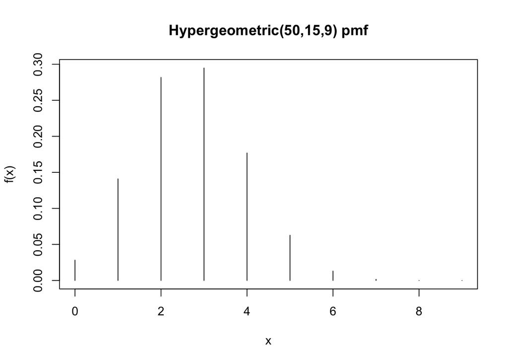

```r
# visualize the distribution
# define the range of the random variable
x <- 0:9
plot(x = x, y = dhyper(x = x, m = 15, n = 35, k = 9), type = "h", xlab = "x", ylab = "f(x)", main = "Hypergeometric(50,15,9) pmf")
```

### Negative binomial distribution

Let $X \sim \text{Negative Binomial}(r = 3, p = 0.3)$.

- pmf: $f(x) = {{x-1} \choose {r-1}} p^r (1-p)^{x-r}$
- In R, (just like with the geometric distribution) negative binomial is counting the number of failures $\Longrightarrow Y = X - r$.

Calculate the following probabilities using `dnbinom()` and `pnbinom()`.

```r
# P(X <= 11)
# -> range of x starts at r, which = 3
# -> size = r
# -> need to convert to y = number of failures (range is 0,1,2,...)
r <- 3
x <- r:11
y <- x - r
sum(dnbinom(x = y, size = r, prob = 0.3))
```

```
[1] 0.6872595
```

```r
pnbinom(q = max(y), size = r, prob = 0.3) # cutoff is the highest x - r = max(y)
```

```
[1] 0.6872595
```

```r
# P(X > 6) = 1 - P(X <= 6)
x <- r:6
y <- x - r
1 - sum(dnbinom(x = y, size = r, prob = 0.3))
```

```
[1] 0.74431
```

```r
1 - pnbinom(q = max(y), size = r, prob = 0.3)
```

```
[1] 0.74431
```

```r
pnbinom(q = max(y), size = r, prob = 0.3, lower.tail = FALSE)
```

```
[1] 0.74431
```

Visualize the distribution

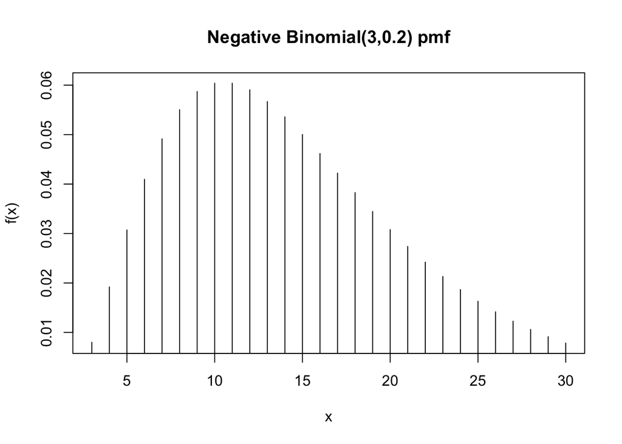

```r
x <- r:30
y <- x - r

# going to plot our version of the NB
# -> so get probabilities according to Y, but match with the corresponding Xs
plot(x = x, y = dnbinom(x = y, size = r, prob = 0.2), type = "h", xlab = "x", ylab = "f(x)", main = "Negative Binomial(3,0.2) pmf")
```

### Gamma distribution

Let $X \sim \text{Gamma}(\alpha = 3.5, \beta = 0.75)$.

Calculate the following probabilities using `pgamma()` (remember we couldn’t find gamma probabilities by hand unless $\alpha$ = whole number (but would require lots of integration by parts)).

```r
# P(X < 5)
pgamma(q = 5, shape = 3.5, rate = 0.75)
```

```
[1] 0.6212631
```

```r
# P(X >= 4)
pgamma(q = 4, shape = 3.5, rate = 0.75, lower.tail = FALSE)
```

```
[1] 0.5397494
```

```r
1 - pgamma(q = 4, shape = 3.5, rate = 0.75)
```

```
[1] 0.5397494
```

```r
# P(2.5 < X < 7)
pgamma(q = 7, shape = 3.5, rate = 0.75) -  pgamma(q = 2.5, shape = 3.5, rate = 0.75)
```

```
[1] 0.6461156
```

Visualize the distribution.

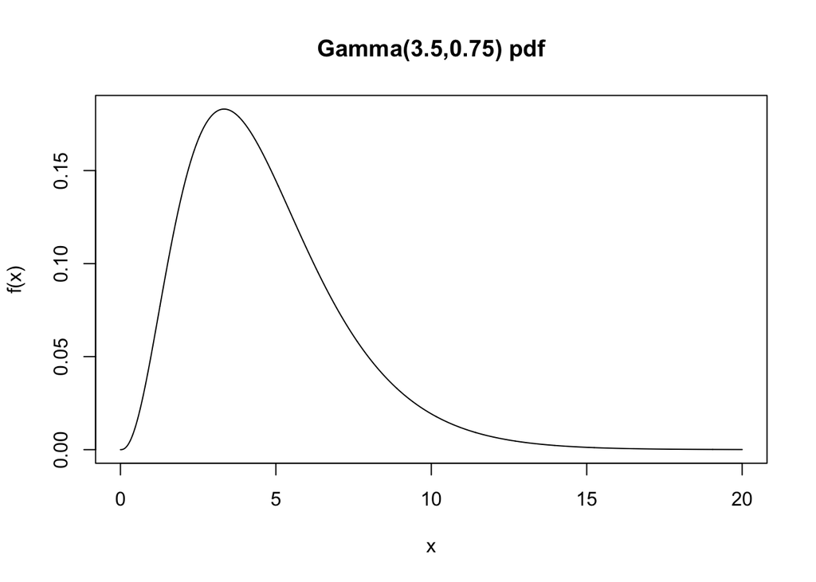

```r
# visualize the distribution
x <- seq(from = 0, to = 20, by = 0.01)
plot(x = x, y =  dgamma(x, shape = 3.5, rate = 0.75), type = "l", xlab = "x", ylab = "f(x)", main = "Gamma(3.5,0.75) pdf")
```